# DEM 5093/7093 GIS - Polygon analysis with R and QGIS - Apportioning Populations

Corey S. Sparks, PhD

24 March, 2021

This example will use R to download American Community Survey summary file tables using the `tidycensus` package. The goal of this example is to illustrate how to use QGIS within R to overlap and intersect different data layers so we can apportion population from one geography to another.

This involves obtaining two layers of geometry, one with a population estimate and the other (target) that does not have an estimate, but for which we desire one.

Simple apportionment relies on dividing the population based on area, and typically works ok, but of course unless population is spread evenly across an area, the estimate will be too low or too high.

### Get a Census developer API Key

Obtain one at http://api.census.gov/data/key_signup.html

### Save your API key to your working directory

use `census_api_key(key = "yourkeyhere", install = T)` one time to install your key for use in `tidycensus`

### ACS data extract

```r
library(tigris)
library(qgisprocess)
library(tidycensus)
library(sf)
library(dplyr)
library(tmap)

qgis_configure()
```

## Load the ACS data for age by sex

Here we get our original estimates data, at the census tract level in Bexar county, TX.

ACS table B01001 is age by sex. I ususally look [at this site](https://www.socialexplorer.com/data/ACS2018_5yr/metadata/?ds=ACS18_5yr) to find table numbers, or the [Census API site](https://api.census.gov/data/2018/acs/acs5.html).

**Our goal is to estimate the total number of children under age 5 in school districts**.

The population estimates are done separately by sex, so we need two tables.

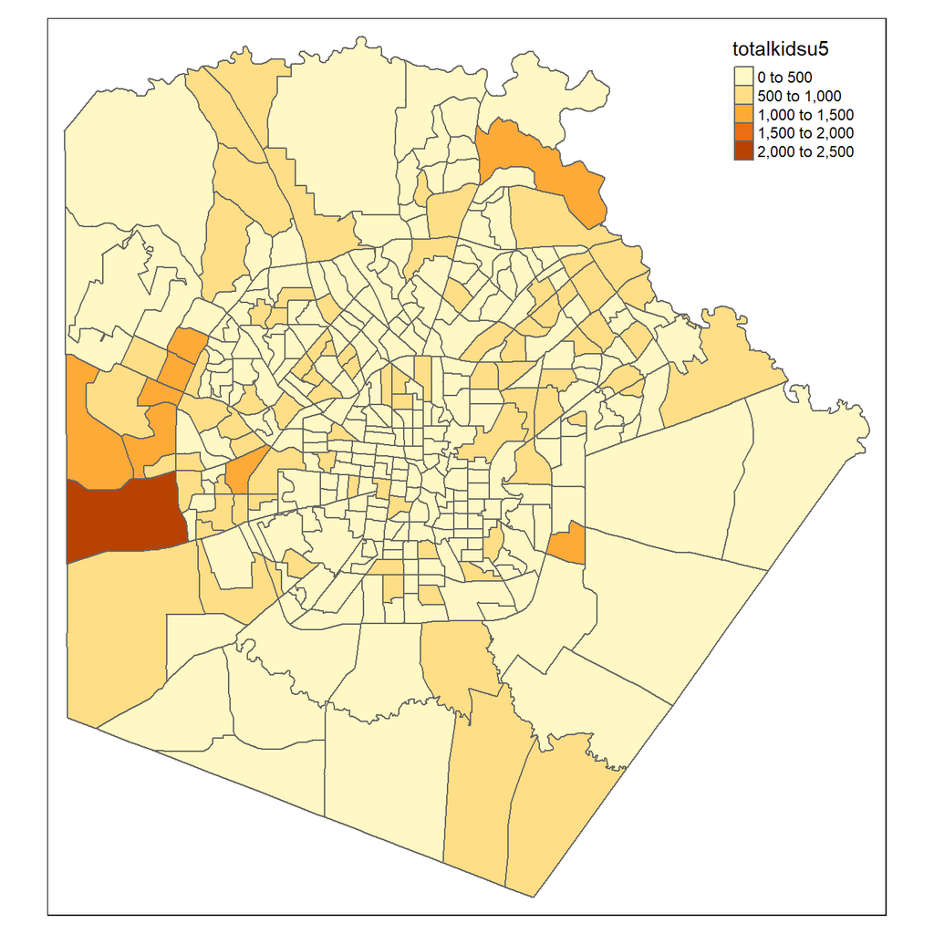

```r
options(tigris_use_cache = TRUE)


age.tract<-get_acs(geography = "tract",
                   state="48",
                   county="Bexar",
                   year =2019,
                   variables  = c("B01001_003E", "B01001_027E"),
                   output="wide",
                   geometry = T)
#mutate, calculate area of each tract, select and project
age.tract<-age.tract%>%
  mutate(totalkidsu5=B01001_003E+B01001_027E,
         totalu5err= sqrt(B01001_003M^2+B01001_027M^2),
         area=st_area(.))%>%
  select(GEOID, totalkidsu5, totalu5err, area)%>%
  st_transform(crs=2278)


tm_shape(age.tract)+
  tm_polygons("totalkidsu5")
```

### Intersecting geographies

When we want to combine information on two spatial layers, we can do a few different things.

The one we’re going to do here is a [**geometric intersection**](http://pro.arcgis.com/en/pro-app/tool-reference/analysis/intersect.htm).

This combines the information from two layers, in the areas in which the two layers overlap. Any areas that don’t overlap are removed.

Since we want to get estimates for school districts, we can download those data:

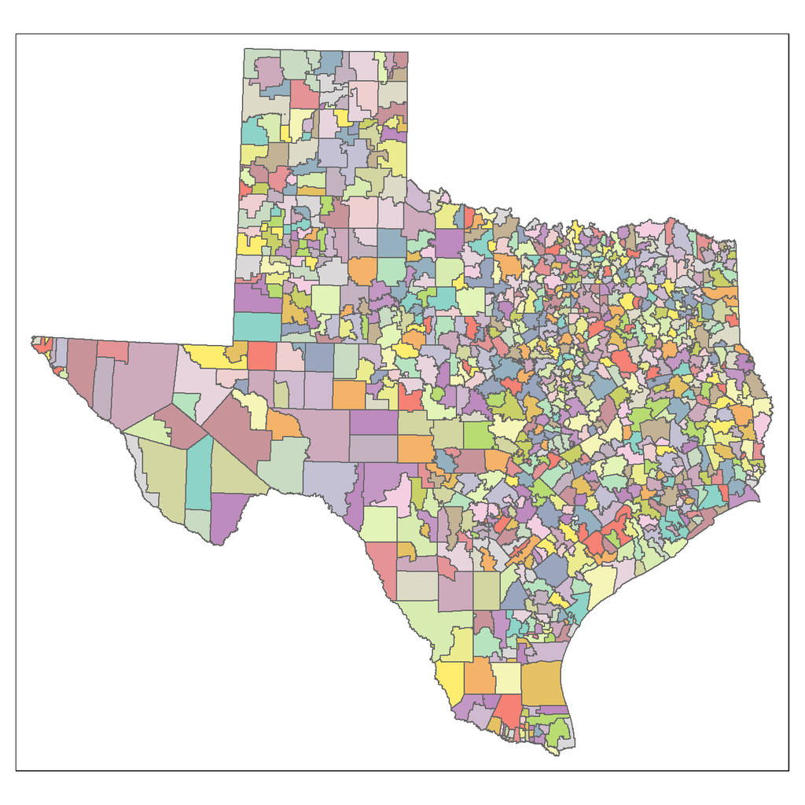

```r
district<-school_districts(state = "TX",
                           type="unified",
                           refresh=T)

district<-st_transform(district,
                       crs=2278 )

district$area_orig<-st_area(district)

tm_shape(district)+
  tm_polygons("NAME", legend.show=FALSE)
```

Since school districts aren’t nested necessarily within counties (why, I have no idea), we have to clip the districts to be within the Bexar county border:

Here we get the county polygon for Bexar county:

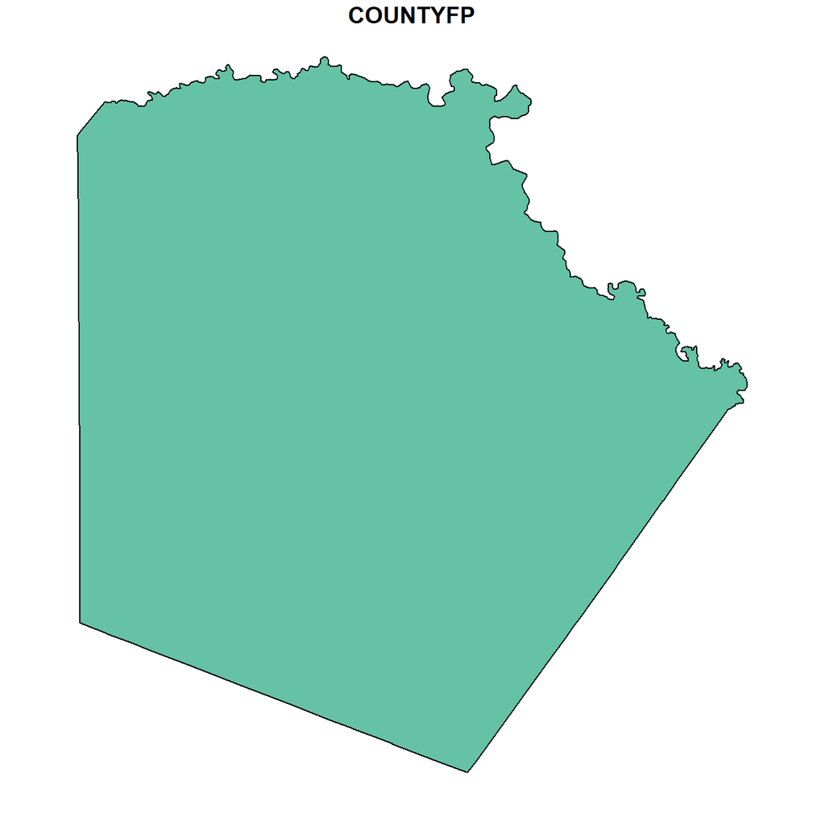

```r
bexarco<-counties(state="TX",
                  cb=T,
                  year=2019)

bexarco<-bexarco[bexarco$COUNTYFP=="029",]

bexarco<-st_transform(bexarco, crs=2278)

plot(bexarco["COUNTYFP"])
```

Here we get the districts in Bexar county using an intersection operation:

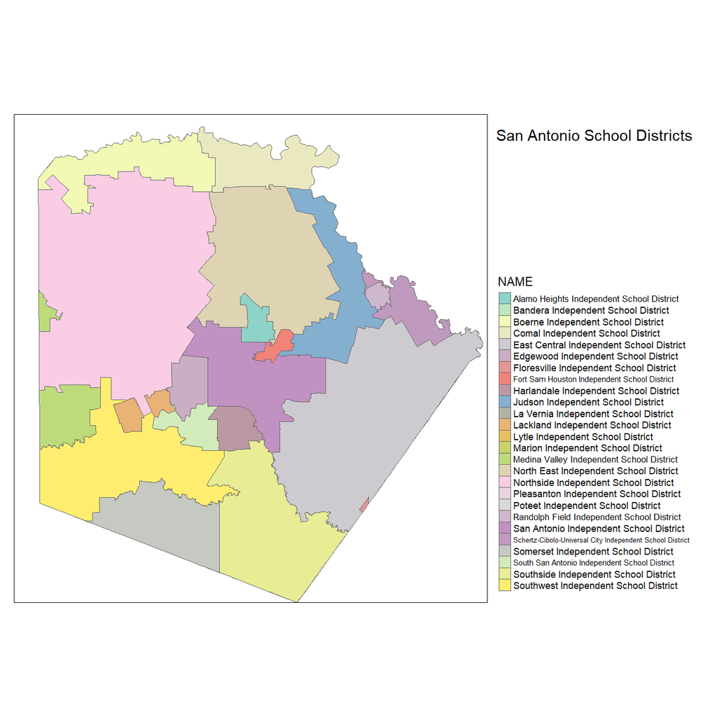

```r
res1<-st_intersection(district, bexarco, tolerance=100000)

res1<-st_buffer(res1, .00001)


tm_shape(res1)+
  tm_polygons("NAME")+
  tm_format("World", title="San Antonio School Districts", legend.outside=TRUE)
```

Now we have our school district areas within Bexar county, now we need to intersect tracts and districts. This can be a time consuming process, so we’re actually just going to use the geometric operations within the `sf` [library](https://cran.r-project.org/web/packages/sf/vignettes/sf1.html#geometrycollection)

```r
sdtract<-st_intersection(res1, age.tract )
tm_shape(sdtract)+
  tm_polygons("NAME")+
  tm_format("World", title="San Antonio School Districts & Tracts", legend.outside=TRUE)
```

```
## Some legend labels were too wide. These labels have been resized to 0.52, 0.48, 0.52, 0.39, 0.47. Increase legend.width (argument of tm_layout) to make the legend wider and therefore the labels larger.
```

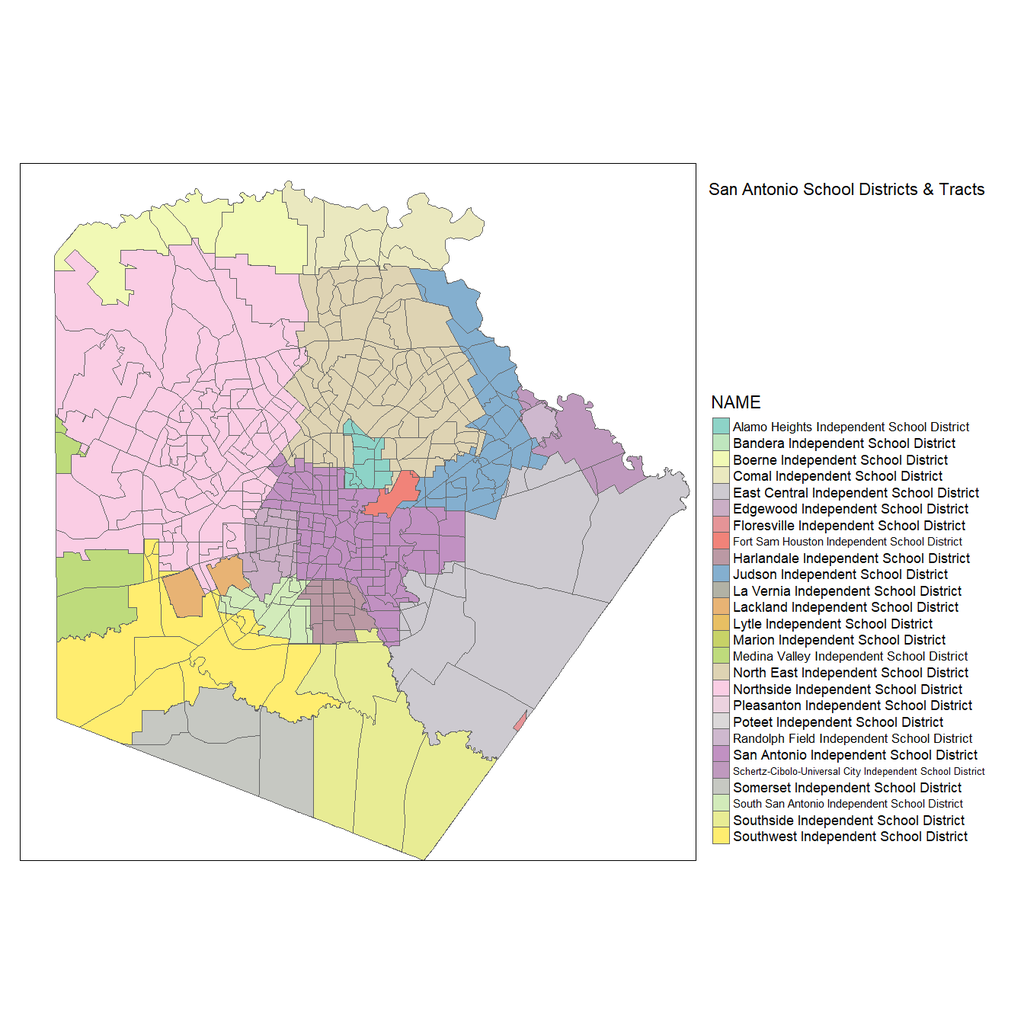

GREAT! And we see the tracts exist within school districts, which was our goal.

Now, some parts of tracts may exist in multiple districts, this is because the two geographies are not nested. We can see this by mapping both layer together:

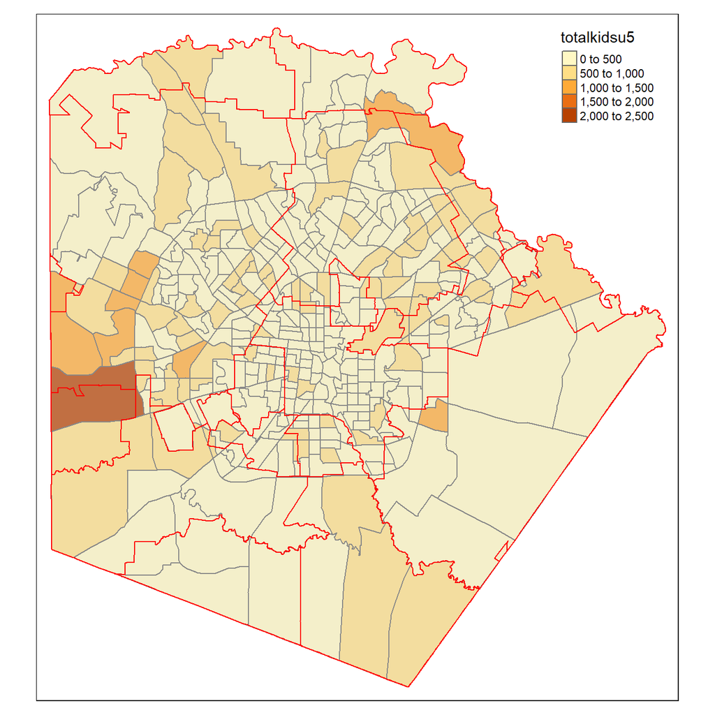

```r
tm_shape(age.tract)+
  tm_polygons("totalkidsu5")+
  tm_shape(res1)+
  tm_polygons(alpha = .3, border.col = "red")
```

## Apportionment or population based on area

So, we can find the ratio of each tract’s area within the school district, and divide it by the original area of the tract. This gives us the proportion of the area of a tract within a given district. Once we have this, we can multiply the population by the proportion, and we will have a proportion of the population of that tract within a district:

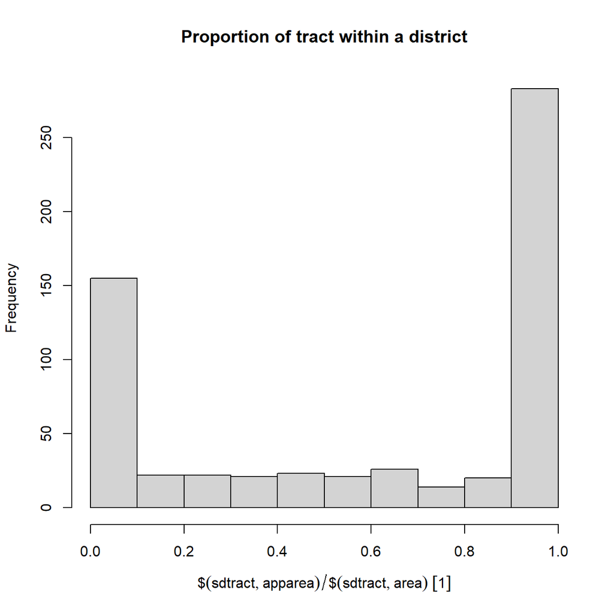

```r
sdtract$apparea<-st_area(sdtract) #area of intersected tracts
sdtract$app_kids<-sdtract$totalkidsu5*(sdtract$apparea/sdtract$area) #apportion population

hist(sdtract$apparea/sdtract$area, main="Proportion of tract within a district")
```

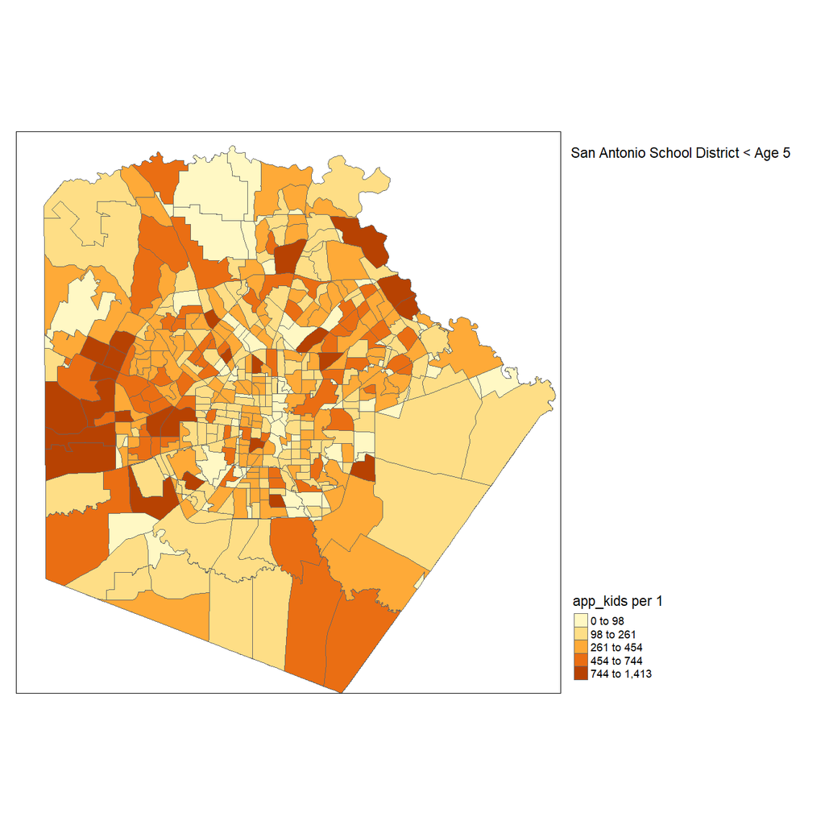

```r
tm_shape(sdtract)+
  tm_polygons("app_kids", style="jenks", n=5)+
  tm_format("World", title="San Antonio School District < Age 5", legend.outside=TRUE)
```

So now we have split our tract populations, we can aggregate the apportioned populations across school districts to get a total population estimate for each district:

```r
sd_ests<-aggregate(app_kids~GEOID, data=sdtract, FUN=sum)

head(sd_ests)
```

|  | GEOID | app_kids |
| --- | --- | --- |
| 1 | 4807590 | 1.991099e+03 [1] |
| 2 | 4809360 | 8.893972e-03 [1] |
| 3 | 4810710 | 1.042260e+03 [1] |
| 4 | 4814730 | 1.504187e+03 [1] |
| 5 | 4817850 | 4.052629e+03 [1] |
| 6 | 4818150 | 4.373249e+03 [1] |

So, i’ve let you on by telling you that we didn’t have estimates for districts, but in fact, the Census generates population estimates for all school districts. So in this case, we can actually check how our estimates compare with *truth*.

```r
#truth
dist_tru<-get_acs(state="TX", geography = "school district (unified)", year=2015, output = "wide",variable = c("B01001_003", "B01001_027"))
distgeo<-school_districts(state="TX", type="unified", year=2015)

dist_tru<-left_join(distgeo, dist_tru, by="GEOID")
dist_tru<-st_transform(dist_tru, crs=2278)
sa_dist_tru<-st_intersection(dist_tru, bexarco)
sa_dist_tru<-sa_dist_tru%>%
  mutate(totalkidsu5=B01001_003E+B01001_027E,
         totalu5err= sqrt(B01001_003M^2+B01001_027M^2))

mdat<-left_join(sa_dist_tru, sd_ests, by="GEOID")
head(mdat)
```

[output not shown]

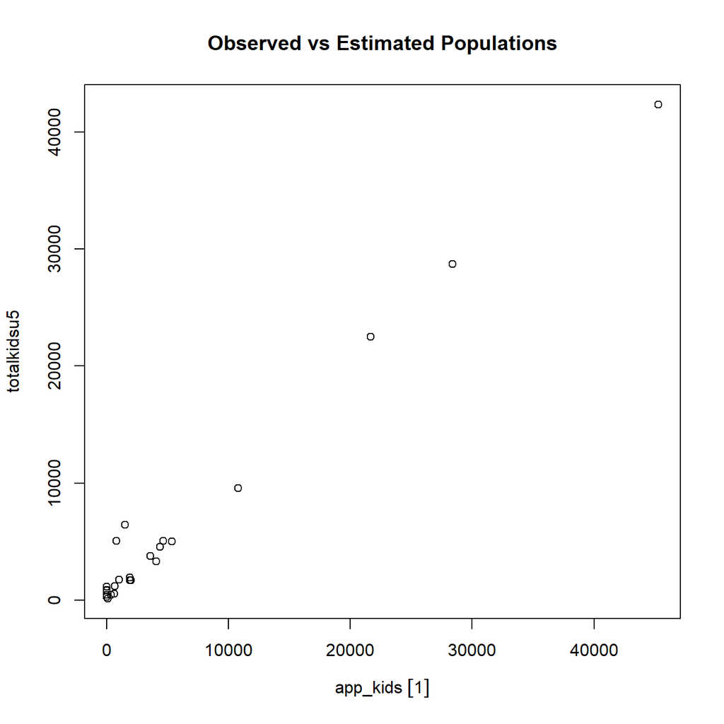

```r
plot(totalkidsu5~app_kids, data=mdat, main="Observed vs Estimated Populations")
```

```r
summary(lm(totalkidsu5~app_kids, data=mdat))
```

```
##
## Call:
## lm(formula = totalkidsu5 ~ app_kids, data = mdat)
##
## Residuals:
##     Min      1Q  Median      3Q     Max
## -1333.2  -789.6  -345.2    67.4  4243.2
##
## Coefficients:
##              Estimate Std. Error t value Pr(>|t|)
## (Intercept) 796.43352  297.63479   2.676   0.0132 *
## app_kids      0.93828    0.02544  36.875   <2e-16 ***
## ---
## Signif. codes:  0 '***' 0.001 '**' 0.01 '*' 0.05 '.' 0.1 ' ' 1
##
## Residual standard error: 1350 on 24 degrees of freedom
## Multiple R-squared:  0.9827, Adjusted R-squared:  0.9819
## F-statistic:  1360 on 1 and 24 DF,  p-value: < 2.2e-16
```

## We did pretty good using apportionment!